# 스터디 발표자료

# 1 Preparations (준비작업)

## 1.1 Libraries

```r
library(data.table)
library(tidyverse)
library(tidymodels)
library(lubridate)
library(stringr)
library(skimr)
library(inspectdf)
library(anomalize) # 시계열 이상치 탐색 패키지
library(stacks) # tidymodels stacking 패키지

theme_set(theme_bw())
```

## 1.2 Data load

데이터는 종헌님께서 정리해주신 텍스트 임베딩이 된 데이터를 불러왔습니다.

```r
file_path <- "./data/"
files <- list.files(file_path)
files
```

```
##  [1] "dust.csv"                        "OBS_ASOS_TIM_20210703160004.csv"
##  [3] "OBS_ASOS_TIM_20210703160026.csv" "OBS_ASOS_TIM_20210703160044.csv"
##  [5] "OBS_ASOS_TIM_20210703160101.csv" "OBS_ASOS_TIM_20210703160134.csv"
##  [7] "OBS_ASOS_TIM_20210703160159.csv" "sample_submission.csv"
##  [9] "test.csv"                        "test_topic.csv"
## [11] "train.csv"                       "train_topic.csv"
```

```r
train <- fread(file.path(file_path, "train_topic.csv"))
test <- fread(file.path(file_path, "test_topic.csv"))
sample_submission <- fread(file.path(file_path, "sample_submission.csv"), encoding = 'UTF-8')
```

```r
train %>% head()
```

```
##        Topic1    Topic2     Topic3     Topic4       일자 요일 본사정원수
## 1: 0.27524975 0.4772573 0.20893200 0.03856096 2016-02-01   월       2601
## 2: 0.08332099 0.7569969 0.10742359 0.05225852 2016-02-02   화       2601
## 3: 0.05434223 0.3348660 0.02937415 0.58141760 2016-02-03   수       2601
## 4: 0.13107020 0.5804020 0.25012821 0.03839954 2016-02-04   목       2601
## 5: 0.44866108 0.4541370 0.04854274 0.04865920 2016-02-05   금       2601
## 6: 0.14503701 0.1670306 0.65087696 0.03705541 2016-02-11   목       2601
##    본사휴가자수 본사출장자수 본사시간외근무명령서승인건수
## 1:           50          150                          238
## 2:           50          173                          319
## 3:           56          180                          111
## 4:          104          220                          355
## 5:          278          181                           34
## 6:          383          143                          417
##    현본사소속재택근무자수 중식계 석식계 clust
## 1:                      0   1039    331     1
## 2:                      0    867    560     1
## 3:                      0   1017    573     1
## 4:                      0    978    525     1
## 5:                      0    925    330     1
## 6:                      0   1045    550     2
```

```r
train %>% glimpse()
```

```
## Rows: 1,163
## Columns: 14
## $ Topic1                       <dbl> 0.27524975, 0.08332099, 0.05434223, 0.131~
## $ Topic2                       <dbl> 0.47725729, 0.75699690, 0.33486602, 0.580~
## $ Topic3                       <dbl> 0.20893200, 0.10742359, 0.02937415, 0.250~
## $ Topic4                       <dbl> 0.03856096, 0.05225852, 0.58141760, 0.038~
## $ 일자                         <date> 2016-02-01, 2016-02-02, 2016-02-03, 2016-0~
## $ 요일                         <chr> "월", "화", "수", "목", "금", "목", "금", "~
## $ 본사정원수                   <int> 2601, 2601, 2601, 2601, 2601, 2601, 2601, 2601~
## $ 본사휴가자수                 <int> 50, 50, 56, 104, 278, 383, 389, 87, 72, 78, 77,~
## $ 본사출장자수                 <int> 150, 173, 180, 220, 181, 143, 156, 204, 236, 25~
## $ 본사시간외근무명령서승인건수 <int> 238, 319, 111, 355, 34, 417, 93, 482, 526, 23, 367, 69,~
## $ 현본사소속재택근무자수       <int> 0, 0, 0, 0, 0, 0, 0, 0, 0, 0, 0, 0, 0, 0, 0, 0, 0, 0~
## $ 중식계                       <int> 1039, 867, 1017, 978, 925, 1045, 909, 1268, ~
## $ 석식계                       <int> 331, 560, 573, 525, 330, 550, 598, 672, 523,~
## $ clust                        <int> 1, 1, 1, 1, 1, 2, 2, 2, 2, 2, 2, 2, 2, 2,~
```

```r
train %>% skim()
```

Data summary

| Name | Piped data |
| --- | --- |
| Number of rows | 1163 |
| Number of columns | 14 |
| Key | NULL |
| _______________________ |  |
| Column type frequency: |  |
| character | 1 |
| Date | 1 |
| numeric | 12 |
| ________________________ |  |
| Group variables | None |

**Variable type: character**

| skim_variable | n_missing | complete_rate | min | max | empty | n_unique | whitespace |
| --- | --- | --- | --- | --- | --- | --- | --- |
| 요일 | 0 | 1 | 1 | 1 | 0 | 5 | 0 |

**Variable type: Date**

| skim_variable | n_missing | complete_rate | min | max | median | n_unique |
| --- | --- | --- | --- | --- | --- | --- |
| 일자 | 0 | 1 | 2016-02-01 | 2021-01-26 | 2018-07-16 | 1163 |

**Variable type: numeric**

| skim_variable | n_missing | complete_rate | mean | sd | p0 | p25 | p50 | p75 | p100 | hist |
| --- | --- | --- | --- | --- | --- | --- | --- | --- | --- | --- |
| Topic1 | 0 | 1 | 0.45 | 0.29 | 0.05 | 0.17 | 0.40 | 0.74 | 0.93 | ▇▅▃▃▆ |
| Topic2 | 0 | 1 | 0.14 | 0.19 | 0.02 | 0.03 | 0.05 | 0.16 | 0.89 | ▇▁▁▁▁ |
| Topic3 | 0 | 1 | 0.23 | 0.23 | 0.02 | 0.06 | 0.10 | 0.33 | 0.91 | ▇▂▁▁▁ |
| Topic4 | 0 | 1 | 0.18 | 0.24 | 0.02 | 0.04 | 0.05 | 0.21 | 0.89 | ▇▁▁▁▁ |
| 본사정원수 | 0 | 1 | 2808.19 | 171.49 | 2601.00 | 2645.00 | 2760.00 | 2962.00 | 3305.00 | ▇▃▃▂▁ |
| 본사휴가자수 | 0 | 1 | 158.94 | 144.85 | 23.00 | 72.00 | 105.00 | 188.00 | 1224.00 | ▇▁▁▁▁ |
| 본사출장자수 | 0 | 1 | 240.59 | 43.70 | 41.00 | 217.00 | 244.00 | 271.50 | 378.00 | ▁▁▇▇▁ |
| 본사시간외근무명령서승인건수 | 0 | 1 | 283.88 | 245.12 | 0.00 | 10.50 | 310.00 | 458.00 | 1044.00 | ▇▅▅▂▁ |
| 현본사소속재택근무자수 | 0 | 1 | 44.74 | 111.15 | 0.00 | 0.00 | 0.00 | 0.00 | 533.00 | ▇▁▁▁▁ |
| 중식계 | 0 | 1 | 891.84 | 210.64 | 296.00 | 758.00 | 880.00 | 1033.00 | 1459.00 | ▁▅▇▅▂ |
| 석식계 | 0 | 1 | 478.06 | 110.82 | 0.00 | 414.00 | 486.00 | 548.00 | 905.00 | ▁▂▇▃▁ |
| clust | 0 | 1 | 2.02 | 0.46 | 1.00 | 2.00 | 2.00 | 2.00 | 3.00 | ▁▁▇▁▁ |

```r
test %>% head()
```

```
##       Topic1    Topic2     Topic3     Topic4       일자 요일 본사정원수
## 1: 0.6560888 0.1457960 0.05648153 0.14163376 2021-01-27   수       2983
## 2: 0.2337927 0.5284721 0.15050582 0.08722937 2021-01-28   목       2983
## 3: 0.2522315 0.1407548 0.26876410 0.33824963 2021-01-29   금       2983
## 4: 0.5739757 0.1617147 0.06296005 0.20134950 2021-02-01   월       2924
## 5: 0.2732185 0.2423056 0.19988960 0.28458631 2021-02-02   화       2924
## 6: 0.5008930 0.1198962 0.10267438 0.27653640 2021-02-03   수       2924
##    본사휴가자수 본사출장자수 본사시간외근무명령서승인건수
## 1:           88          182                            5
## 2:          104          212                          409
## 3:          270          249                            0
## 4:          108          154                          538
## 5:           62          186                          455
## 6:           59          199                            5
##    현본사소속재택근무자수 중식계 석식계 clust
## 1:                    358     NA     NA     3
## 2:                    348     NA     NA     3
## 3:                    294     NA     NA     3
## 4:                    322     NA     NA     3
## 5:                    314     NA     NA     3
## 6:                    286     NA     NA     3
```

```r
test %>% skim()
```

Data summary

| Name | Piped data |
| --- | --- |
| Number of rows | 50 |
| Number of columns | 14 |
| Key | NULL |
| _______________________ |  |
| Column type frequency: |  |
| character | 1 |
| Date | 1 |
| logical | 2 |
| numeric | 10 |
| ________________________ |  |
| Group variables | None |

**Variable type: character**

| skim_variable | n_missing | complete_rate | min | max | empty | n_unique | whitespace |
| --- | --- | --- | --- | --- | --- | --- | --- |
| 요일 | 0 | 1 | 1 | 1 | 0 | 5 | 0 |

**Variable type: Date**

| skim_variable | n_missing | complete_rate | min | max | median | n_unique |
| --- | --- | --- | --- | --- | --- | --- |
| 일자 | 0 | 1 | 2021-01-27 | 2021-04-09 | 2021-03-06 | 50 |

**Variable type: logical**

| skim_variable | n_missing | complete_rate | mean | count |
| --- | --- | --- | --- | --- |
| 중식계 | 50 | 0 | NaN | : |
| 석식계 | 50 | 0 | NaN | : |

**Variable type: numeric**

| skim_variable | n_missing | complete_rate | mean | sd | p0 | p25 | p50 | p75 | p100 | hist |
| --- | --- | --- | --- | --- | --- | --- | --- | --- | --- | --- |
| Topic1 | 0 | 1 | 0.44 | 0.18 | 0.18 | 0.28 | 0.45 | 0.60 | 0.74 | ▇▃▆▅▆ |
| Topic2 | 0 | 1 | 0.20 | 0.13 | 0.05 | 0.12 | 0.15 | 0.23 | 0.61 | ▇▃▂▁▁ |
| Topic3 | 0 | 1 | 0.10 | 0.06 | 0.04 | 0.06 | 0.08 | 0.11 | 0.28 | ▇▅▁▁▁ |
| Topic4 | 0 | 1 | 0.26 | 0.19 | 0.07 | 0.11 | 0.18 | 0.37 | 0.69 | ▇▂▂▂▂ |
| 본사정원수 | 0 | 1 | 2956.84 | 24.97 | 2924.00 | 2924.00 | 2974.00 | 2975.00 | 2983.00 | ▅▁▁▁▇ |
| 본사휴가자수 | 0 | 1 | 129.52 | 84.07 | 50.00 | 78.25 | 95.00 | 137.50 | 489.00 | ▇▁▂▁▁ |
| 본사출장자수 | 0 | 1 | 209.22 | 39.45 | 131.00 | 176.50 | 202.50 | 245.25 | 279.00 | ▂▇▆▅▆ |
| 본사시간외근무명령서승인건수 | 0 | 1 | 380.14 | 346.56 | 0.00 | 1.00 | 465.50 | 681.00 | 1003.00 | ▇▁▃▅▂ |
| 현본사소속재택근무자수 | 0 | 1 | 298.14 | 52.06 | 179.00 | 257.25 | 300.00 | 333.25 | 413.00 | ▁▇▇▇▂ |
| clust | 0 | 1 | 2.98 | 0.14 | 2.00 | 3.00 | 3.00 | 3.00 | 3.00 | ▁▁▁▁▇ |

# 2 데이터 전처리

## 2.1 날짜변수 생성

1기 분들이 발표해주신 유튜브 영상을 참고해서 year, month, day, weekday 변수를 생성했습니다.

```r
train %>%
  select(-요일) %>%
  mutate(일자 = ymd(일자),
           year = year(일자),
           month = month(일자),
           day = day(일자),
           wday = wday(일자)) %>%
  select(일자, year, month, wday, day, everything()) -> train


test %>%
  select(-요일) %>%
  mutate(일자 = ymd(일자),
           year = year(일자),
           month = month(일자),
           day = day(일자),
           wday = wday(일자)) %>%
  select(일자, year, month, wday, day, everything()) -> test
```

# 3 EDA

## 3.1 barplot, boxplot function

```r
bar_plot <- function(data, var){
  data %>%
  ggplot(aes({{var}}))+
  geom_bar() +
  aes(stringr::str_wrap({{var}}, 10)) +
  geom_label(stat = 'count', aes(label = ..count..)) +
  xlab('{{var}}')
}

box_plot <- function(data, var){
  if ('{{var}}' == str_detect('{{var}}', 'lunch')) {
    data %>%
      ggplot(aes(x = {{var}}, y = 중식계)) +
      geom_boxplot(aes(fill = {{var}}), show.legend = F) +
      aes(stringr::str_wrap({{var}}, 10)) +
      xlab('')
    } else {
      data %>%
        ggplot(aes(x = {{var}}, y = 석식계)) +
        geom_boxplot(aes(fill = {{var}}), show.legend = F) +
        aes(stringr::str_wrap({{var}}, 10)) +
        xlab('')
      }
}
```

# 4 연도별 공휴일

**2016**

| 명칭 | 날짜 | 명칭 | 날짜 |
| --- | --- | --- | --- |
| 신정 | 1.1 | 제헌절 | 7.17 |
| 설날 | 2.7~2.9 | 광복절 | 8.15 |
| 삼일절 | 3.1 | 추석 | 9.14~9.16 |
| 어린이날 | 5.5 | 개천절 | 10.3 |
| 석가탄신일 | 5.14 | 한글날 | 10.9 |
| 현충일 | 6.6 | 기독탄신일 | 12.25 |
| 대체공휴일 | 2.10 | 국회의원선거일 | 4.13 |

**2017**

| 명칭 | 날짜 | 명칭 | 날짜 |
| --- | --- | --- | --- |
| 신정 | 1.1 | 제헌절 | 7.17 |
| 설날 | 1.27~1.29 | 광복절 | 8.15 |
| 삼일절 | 3.1 | 추석 | 10.3~10.5 |
| 어린이날 | 5.5 | 개천절 | 10.3 |
| 석가탄신일 | 5.3 | 한글날 | 10.9 |
| 현충일 | 6.6 | 기독탄신일 | 12.25 |
| 대체공휴일 | 1.30, 10.6 | 대통령선거일 | 12.20 |

**2018**

| 명칭 | 날짜 | 명칭 | 날짜 |
| --- | --- | --- | --- |
| 신정 | 1.1 | 제헌절 | 7.17 |
| 설날 | 2.15~2.17 | 광복절 | 8.15 |
| 삼일절 | 3.1 | 추석 | 9.23~9.26 |
| 어린이날 | 5.5 | 개천절 | 10.3 |
| 석가탄신일 | 5.22 | 한글날 | 10.9 |
| 현충일 | 6.6 | 기독탄신일 | 12.25 |
| 대체공휴일 | 5.7 | 지방선거 | 6.13 |

**2019**

| 명칭 | 날짜 | 명칭 | 날짜 |
| --- | --- | --- | --- |
| 신정 | 1.1 | 제헌절 | 7.17 |
| 설날 | 2.4~2.6 | 광복절 | 8.15 |
| 삼일절 | 3.1 | 추석 | 9.12~9.14 |
| 어린이날 | 5.5 | 개천절 | 10.3 |
| 석가탄신일 | 5.12 | 한글날 | 10.9 |
| 현충일 | 6.6 | 기독탄신일 | 12.25 |
| 대체공휴일 | 5.6 |  |  |

**2020**

| 명칭 | 날짜 | 명칭 | 날짜 |
| --- | --- | --- | --- |
| 신정 | 1.1 | 제헌절 | 7.17 |
| 설날 | 1.24~1.26 | 광복절 | 8.15 |
| 삼일절 | 3.1 | 추석 | 9.30~10.2 |
| 어린이날 | 5.5 | 개천절 | 10.3 |
| 석가탄신일 | 4.30 | 한글날 | 10.9 |
| 현충일 | 6.6 | 기독탄신일 | 12.25 |
| 대체공휴일 | 1.27 | 국회의원선거일 | 4.15 |

# 5 anomaly detection

## 5.1 석식계

```
## Converting from tbl_df to tbl_time.
## Auto-index message: index = 일자
```

```
## frequency = 5 days
```

```
## trend = 58 days
```

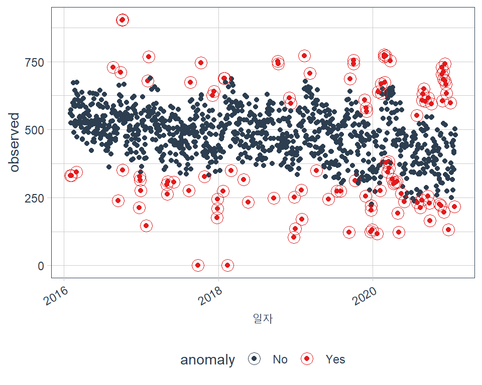

```r
train %>%
  as_tibble() %>%
  select(일자, 석식계) %>%
  time_decompose(석식계) %>%
  anomalize(remainder, alpha = 0.25, max_anoms = 0.1) %>%
  time_recompose() %>%
  plot_anomalies()
```

```r
train %>%
  as_tibble() %>%
  select(일자, 석식계) %>%
  time_decompose(석식계, merge = T) %>%
  anomalize(remainder, alpha = 0.25, max_anoms = 0.1) %>%
  time_recompose() %>%
  filter(anomaly == 'Yes') -> anomaly_data
```

```
## Converting from tbl_df to tbl_time.
## Auto-index message: index = 일자
```

```
## frequency = 5 days
```

```
## trend = 58 days
```

```r
anomaly_data
```

```
## # A time tibble: 116 x 11
## # Index: 일자
##    일자       석식계 observed season trend remainder remainder_l1 remainder_l2
##    <date>      <int>    <dbl>  <dbl> <dbl>     <dbl>        <dbl>        <dbl>
##  1 2016-02-01    331      331 -4.87   557.     -221.        -133.         131.
##  2 2016-02-05    330      330 -0.920  557.     -226.        -133.         131.
##  3 2016-02-29    344      344 -0.945  557.     -212.        -133.         131.
##  4 2016-08-22    729      729  6.60   514.      208.        -133.         131.
##  5 2016-09-13    238      238 -0.945  544.     -305.        -133.         131.
##  6 2016-09-26    710      710  0.126  545.      165.        -133.         131.
##  7 2016-10-04    902      902  0.126  543.      359.        -133.         131.
##  8 2016-10-05    905      905 -0.920  543.      363.        -133.         131.
##  9 2016-10-06    352      352 -4.87   542.     -186.        -133.         131.
## 10 2016-12-22    213      213 -0.920  480.     -266.        -133.         131.
## # ... with 106 more rows, and 3 more variables: anomaly <chr>,
## #   recomposed_l1 <dbl>, recomposed_l2 <dbl>
```

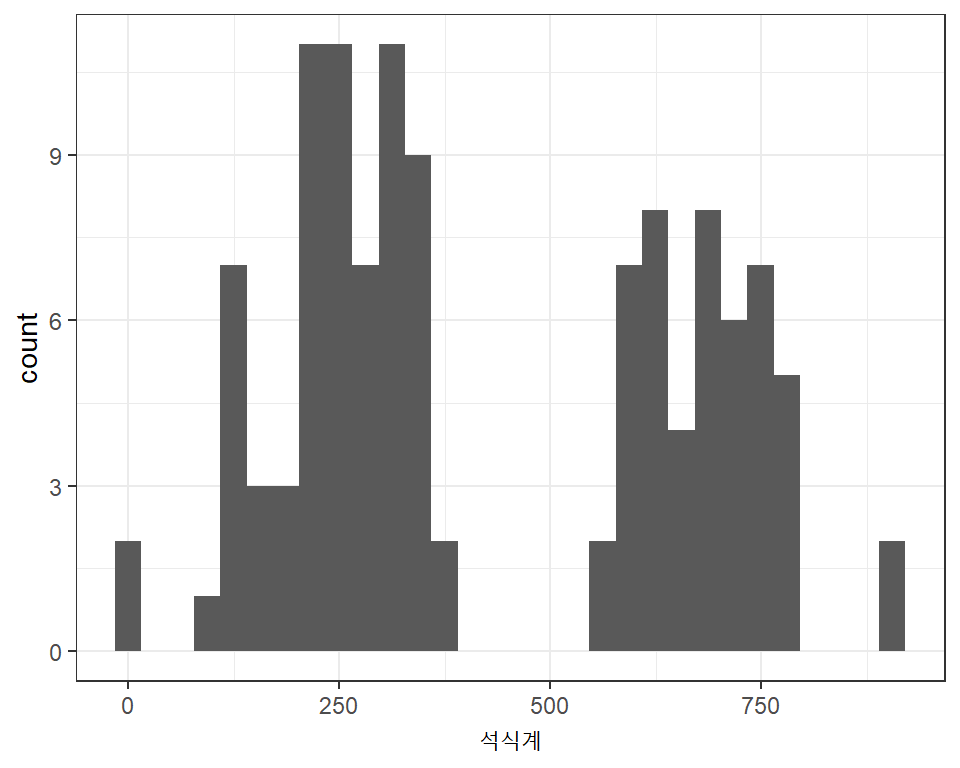

```r
anomaly_data %>%
  ggplot(aes(x = 석식계)) + geom_histogram()
```

```r
train$석식계[train$석식계 == 0] %>% NROW()
```

```
## [1] 2
```

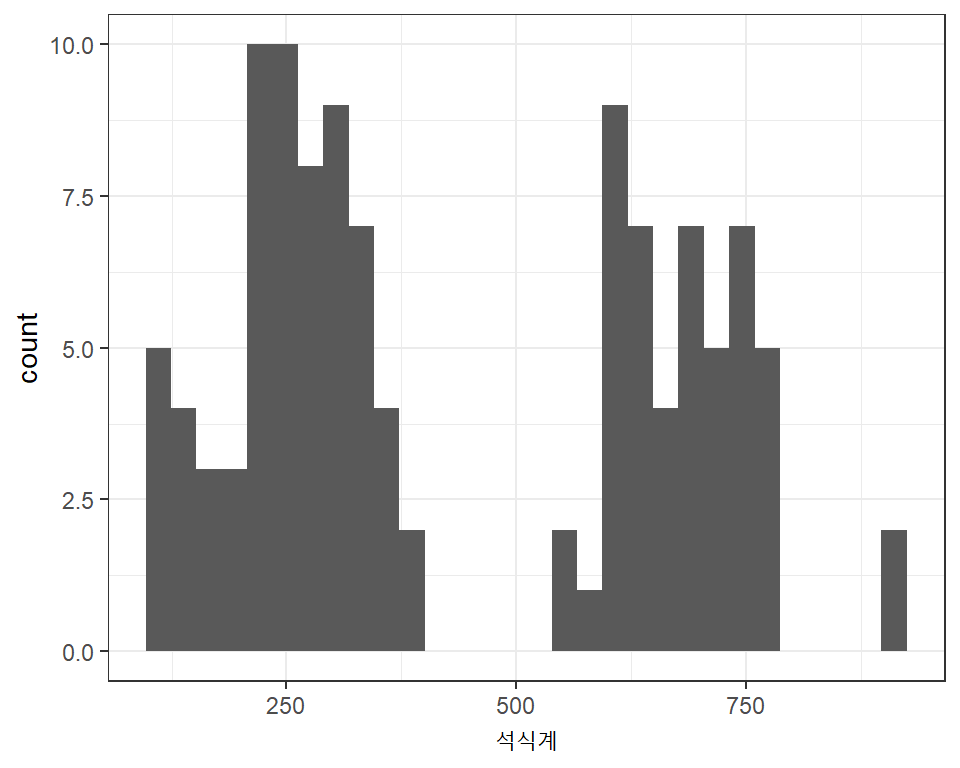

```r
anomaly_data %>%
  filter(!석식계 == 0) %>%
  ggplot(aes(x = 석식계)) + geom_histogram()
```

```r
anomaly_data %>%
  filter(!석식계 == 0) -> anomaly_data2
```

공휴일 다음날은 석식을 먹는 사람이 많음 공휴일 전날은 석식을 먹지 않는 사람이 많음

```r
anomaly_data2 %>%
  filter(석식계 <= 125)
```

```
## # A time tibble: 5 x 11
## # Index: 일자
##   일자       석식계 observed season trend remainder remainder_l1 remainder_l2
##   <date>      <int>    <dbl>  <dbl> <dbl>     <dbl>        <dbl>        <dbl>
## 1 2018-12-24    104      104 -0.920  447.     -342.        -133.         131.
## 2 2019-09-11    123      123 -0.945  501.     -377.        -133.         131.
## 3 2019-12-23    124      124 -0.945  386.     -261.        -133.         131.
## 4 2020-01-23    117      117 -0.945  423.     -305.        -133.         131.
## 5 2020-05-04    123      123 -0.945  458.     -334.        -133.         131.
## # ... with 3 more variables: anomaly <chr>, recomposed_l1 <dbl>,
## #   recomposed_l2 <dbl>
```

```r
anomaly_data2 %>%
  filter(석식계 >= 750)
```

```
## # A time tibble: 10 x 11
## # Index: 일자
##    일자       석식계 observed season trend remainder remainder_l1 remainder_l2
##    <date>      <int>    <dbl>  <dbl> <dbl>     <dbl>        <dbl>        <dbl>
##  1 2016-10-04    902      902  0.126  543.      359.        -133.         131.
##  2 2016-10-05    905      905 -0.920  543.      363.        -133.         131.
##  3 2017-02-06    768      768 -0.945  535.      234.        -133.         131.
##  4 2018-10-10    751      751  0.126  499.      252.        -133.         131.
##  5 2019-02-11    772      772 -0.945  529.      244.        -133.         131.
##  6 2019-10-04    755      755 -0.920  488.      268.        -133.         131.
##  7 2020-02-24    767      767  6.60   509.      251.        -133.         131.
##  8 2020-02-25    776      776 -0.945  513.      264.        -133.         131.
##  9 2020-03-02    771      771 -4.87   523.      253.        -133.         131.
## 10 2020-03-24    754      754  6.60   534.      213.        -133.         131.
## # ... with 3 more variables: anomaly <chr>, recomposed_l1 <dbl>,
## #   recomposed_l2 <dbl>
```

## 5.2 중식계

```
## Converting from tbl_df to tbl_time.
## Auto-index message: index = 일자
```

```
## frequency = 5 days
```

```
## trend = 58 days
```

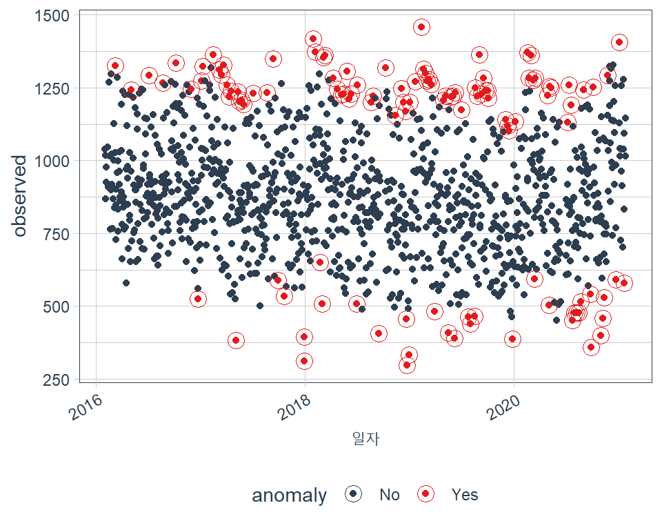

```r
train %>%
  as_tibble() %>%
  select(일자, 중식계) %>%
  time_decompose(중식계) %>%
  anomalize(remainder, alpha = 0.25, max_anoms = 0.1) %>%
  time_recompose() %>%
  plot_anomalies()
```

```r
train %>%
  as_tibble() %>%
  select(일자, 중식계) %>%
  time_decompose(중식계, merge = T) %>%
  anomalize(remainder, alpha = 0.25, max_anoms = 0.1) %>%
  time_recompose() %>%
  filter(anomaly == 'Yes') -> anomaly_data3
```

```
## Converting from tbl_df to tbl_time.
## Auto-index message: index = 일자
```

```
## frequency = 5 days
```

```
## trend = 58 days
```

```r
anomaly_data3
```

```
## # A time tibble: 116 x 11
## # Index: 일자
##    일자       중식계 observed  season trend remainder remainder_l1 remainder_l2
##    <date>      <int>    <dbl>   <dbl> <dbl>     <dbl>        <dbl>        <dbl>
##  1 2016-03-07   1326     1326  16.8    950.      359.        -271.         272.
##  2 2016-05-02   1242     1242 -18.6    911.      350.        -271.         272.
##  3 2016-07-04   1292     1292   0.142  918.      374.        -271.         272.
##  4 2016-08-22   1266     1266  16.8    905.      344.        -271.         272.
##  5 2016-10-05   1336     1336 -10.3    987.      359.        -271.         272.
##  6 2016-11-28   1246     1246   0.142  905.      341.        -271.         272.
##  7 2016-12-22    524      524 -10.3    914.     -379.        -271.         272.
##  8 2017-01-02   1273     1273 -18.6    931.      360.        -271.         272.
##  9 2017-01-09   1322     1322 -18.6    952.      389.        -271.         272.
## 10 2017-02-13   1364     1364   0.142 1000.      364.        -271.         272.
## # ... with 106 more rows, and 3 more variables: anomaly <chr>,
## #   recomposed_l1 <dbl>, recomposed_l2 <dbl>
```

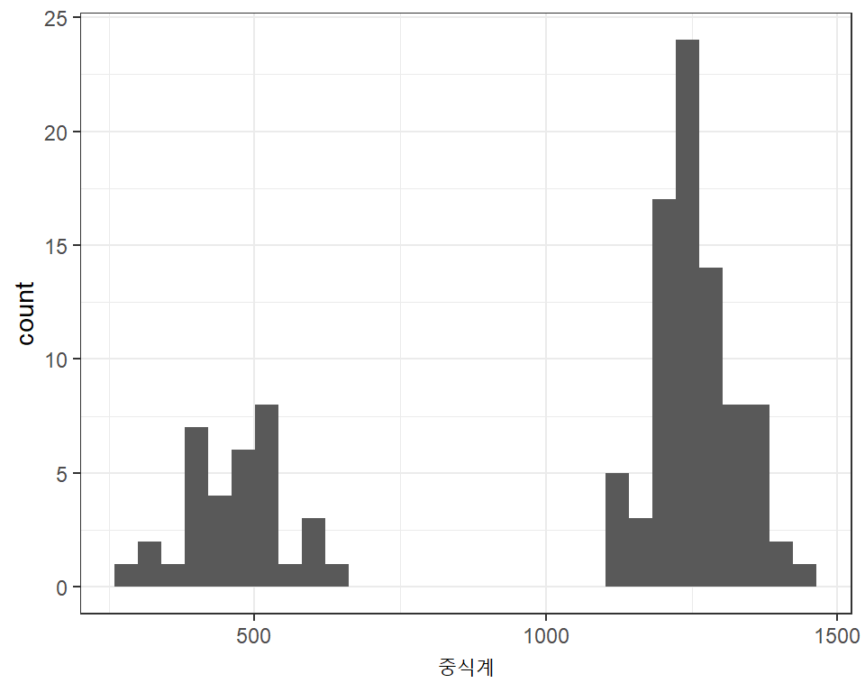

```r
anomaly_data3 %>%
  ggplot(aes(x = 중식계)) + geom_histogram()
```

```r
train$중식계[train$증식계 == 0] %>% NROW()
```

```
## [1] 0
```

공휴일 다음날은 석식을 먹는 사람이 많음 공휴일 전날은 석식을 먹지 않는 사람이 많음

```r
anomaly_data3 %>%
  filter(중식계 <= 500)
```

```
## # A time tibble: 21 x 11
## # Index: 일자
##    일자       중식계 observed  season trend remainder remainder_l1 remainder_l2
##    <date>      <int>    <dbl>   <dbl> <dbl>     <dbl>        <dbl>        <dbl>
##  1 2017-05-04    383      383 -10.3    843.     -449.        -271.         272.
##  2 2017-12-28    311      311 -18.6    868.     -539.        -271.         272.
##  3 2017-12-29    394      394  16.8    870.     -493.        -271.         272.
##  4 2018-09-14    405      405   0.142  892.     -487.        -271.         272.
##  5 2018-12-21    456      456  11.9    805.     -361.        -271.         272.
##  6 2018-12-24    296      296 -10.3    808.     -501.        -271.         272.
##  7 2018-12-31    332      332   0.142  816.     -484.        -271.         272.
##  8 2019-03-29    481      481  11.9    884.     -415.        -271.         272.
##  9 2019-05-17    408      408 -18.6    837.     -411.        -271.         272.
## 10 2019-06-07    389      389  11.9    825.     -448.        -271.         272.
## # ... with 11 more rows, and 3 more variables: anomaly <chr>,
## #   recomposed_l1 <dbl>, recomposed_l2 <dbl>
```

```r
anomaly_data3 %>%
  filter(중식계 >= 1250)
```

```
## # A time tibble: 39 x 11
## # Index: 일자
##    일자       중식계 observed  season trend remainder remainder_l1 remainder_l2
##    <date>      <int>    <dbl>   <dbl> <dbl>     <dbl>        <dbl>        <dbl>
##  1 2016-03-07   1326     1326  16.8    950.      359.        -271.         272.
##  2 2016-07-04   1292     1292   0.142  918.      374.        -271.         272.
##  3 2016-08-22   1266     1266  16.8    905.      344.        -271.         272.
##  4 2016-10-05   1336     1336 -10.3    987.      359.        -271.         272.
##  5 2017-01-02   1273     1273 -18.6    931.      360.        -271.         272.
##  6 2017-01-09   1322     1322 -18.6    952.      389.        -271.         272.
##  7 2017-02-13   1364     1364   0.142 1000.      364.        -271.         272.
##  8 2017-03-06   1311     1311 -18.6    970.      360.        -271.         272.
##  9 2017-03-13   1295     1295 -18.6    952.      362.        -271.         272.
## 10 2017-03-20   1328     1328 -18.6    934.      413.        -271.         272.
## # ... with 29 more rows, and 3 more variables: anomaly <chr>,
## #   recomposed_l1 <dbl>, recomposed_l2 <dbl>
```

# 6 날씨 데이터 정제

기온, 강수량, 풍속, 습도, 증기압, 이슬점온도, 현지기압, 해면기압, 일조, 일사, 적설, 시정 변수 생성(진주시 기준)

기상자료개방포털 -> 종관기상관측(ASOS) https://data.kma.go.kr/data/grnd/selectAsosRltmList.do?pgmNo=36

## 6.1 날씨 데이터 병합

```r
weather2016 <- fread(file.path(file_path, "OBS_ASOS_TIM_20210703160004.csv"))
weather2017 <- fread(file.path(file_path, "OBS_ASOS_TIM_20210703160026.csv"))
weather2018 <- fread(file.path(file_path, "OBS_ASOS_TIM_20210703160044.csv"))
weather2019 <- fread(file.path(file_path, "OBS_ASOS_TIM_20210703160101.csv"))
weather2020 <- fread(file.path(file_path, "OBS_ASOS_TIM_20210703160134.csv"))
weather2021 <- fread(file.path(file_path, "OBS_ASOS_TIM_20210703160159.csv"))

weather <- weather2016 %>%
        bind_rows(weather2017) %>%
        bind_rows(weather2018) %>%
        bind_rows(weather2019) %>%
        bind_rows(weather2020) %>%
        bind_rows(weather2021)

weather %>% names()
```

```
##  [1] "지점"            "지점명"          "일시"            "기온(°C)"
##  [5] "강수량(mm)"      "풍속(m/s)"       "습도(%)"         "증기압(hPa)"
##  [9] "이슬점온도(°C)" "현지기압(hPa)"   "해면기압(hPa)"   "일조(hr)"
## [13] "일사(MJ/m2)"     "적설(cm)"        "시정(10m)"
```

```r
weather %>%
        rename("일자" = "일시", "기온" = "기온(°C)", "강수량" = "강수량(mm)", "풍속" = "풍속(m/s)",
               "습도" = "습도(%)", "증기압" =  "증기압(hPa)", "이슬점온도" = "이슬점온도(°C)",
               "현지기압" = "현지기압(hPa)", "해면기압" = "해면기압(hPa)","일조" = "일조(hr)",
               "일사" = "일사(MJ/m2)", "적설" = "적설(cm)", "시정" = "시정(10m)") -> weather
```

## 6.2 날짜 변수 생성

```r
weather %>%
        mutate(
                일자 = ymd_hm(일자),
                year = year(일자),
                month = month(일자),
                day = day(일자),
                hour = hour(일자)
                ) -> weather
```

## 6.3 불필요한 변수 삭제

적설 변수의 경우 적설량이 거의 없기 때문에 삭제

```r
weather$적설[weather$적설 %>% complete.cases()] # 적설량이 거의 없기 때문에 제외
```

```
##  [1] 0.0 1.1 0.2 0.4 1.9 3.1 2.6 2.3 1.9 1.4 1.1 0.7 0.2 0.3
```

```r
weather %>% select(-적설) -> weather
```

증기압, 현지기압, 해면기압, 일조 일사 변수 삭제 시정은 미세먼지 및 기상현상(박무 및 연무)와 관련이 있으므로 남겨둠

```r
weather %>% names()
```

```
##  [1] "지점"       "지점명"     "일자"       "기온"       "강수량"
##  [6] "풍속"       "습도"       "증기압"     "이슬점온도" "현지기압"
## [11] "해면기압"   "일조"       "일사"       "시정"       "year"
## [16] "month"      "day"        "hour"
```

```r
weather %>%
        select(-c(지점, 지점명, 증기압, 현지기압, 해면기압, 일조, 일사)) %>%
        select(일자, year, month, day, hour, everything()) -> weather
```

## 6.4 결측치 채우기

날씨 변수 값이 0일 경우 NA로 코딩되므로 0으로 변환

```r
weather %>% is.na() %>% colSums()
```

```
##       일자       year      month        day       hour       기온     강수량
##          0          0          0          0          0         36      41437
##       풍속       습도 이슬점온도       시정
##         71         13         29        127
```

```r
weather %>%
        mutate_at(vars(기온, 강수량, 풍속, 습도, 이슬점온도, 시정), replace_na, 0) -> weather
weather %>% is.na() %>% colSums()
```

```
##       일자       year      month        day       hour       기온     강수량
##          0          0          0          0          0          0          0
##       풍속       습도 이슬점온도       시정
##          0          0          0          0
```

## 6.5 불쾌지수, 체감온도, 폭염 변수 생성

$\text{불쾌지수} = 1.8 \times \text{기온} - 0.55 \times (1 - \text{상대습도(%)})\times (1.8 \times \text{기온} - 26) + 32$

| 단계 | 지수 범위 |
| --- | --- |
| 매우 높음 | 80 이상 |
| 높음 | 75~80 미만 |
| 보통 | 68~75 미만 |
| 낮음 | 68 미만 |

상대습도 : 이슬점 온도, 기온 변수를 이용해서 **humidity package**로 구할 수 있음

폭염: 5~9월에 체감온도 33도 이상인 날이 2일 이상 지속될 경우 폭염 주의보, 35도 이상인 날이 2일 이상 지속될 경우 폭염 경보

체감온도 기준 : https://www.weather.go.kr/plus/life/li_asset/HELP/basic/help_01_07.jsp 불쾌지수 기준 : http://www.psychiatricnews.net/news/articleView.html?idxno=10116 폭염기준 : [<https://ko.wikipedia.org/wiki/%ED%8F%AD%EC%97%BC>](https://ko.wikipedia.org/wiki/%ED%8F%AD%EC%97%BC) humidity package: https://cran.r-project.org/web/packages/humidity/humidity.pdf

```r
library(humidity)

weather %>%
        mutate(
                상대습도 = humidity::RH(t = 기온, Td = 이슬점온도, isK = FALSE)*0.01,
                불쾌지수 = (1.8*기온) - (0.55*(1-상대습도))*((1.8*기온)-26) + 32,
                풍속 = 풍속*3.6, # m/s -> km/h
                체감온도 = 13.2 + (0.6215*기온) - (11.37*풍속^0.16) + (0.3965*풍속^0.16*기온),
                폭염 = if_else(체감온도>=33, 1, 0)
                   ) -> weather
```

## 6.6 day 기준으로 group by

날씨 변수는 hour 기준으로 생성되었기 때문에 raw data의 day 기준으로 group by 해줌 group by를 할 때 점심, 저녁 한시간 전후의 날씨만 고려함 폭염 변수의 경우 폭염 기준에 따라 이진변수로 코딩함

```r
weather %>%
        select(일자, year, month, day, hour, everything()) %>%

        # 점심, 저녁 식사 시간 한시간 전까지만 filtering
        filter(hour >= 11 & hour <= 14 | hour>=16 & hour <=19) %>%
        group_by(year, month, day) %>%
        summarise(
                체감온도 = mean(체감온도),
                불쾌지수 = mean(불쾌지수),
                폭염 = mean(폭염),
                강수량 = mean(강수량),
                시정 = mean(시정)) %>%
        ungroup() -> weather_tbl
weather_tbl %>%
        mutate(폭염 = if_else(폭염 != 0, 1, 0)) -> weather_tbl
```

## 6.7 미세먼지 데이터 정제

기상자료개방포털에서 다운받은 데이터는 pm2.5 기준임

[output not shown]

미세먼지 데이터 출처 https://data.kma.go.kr/data/climate/selectDustRltmList.do?pgmNo=68

미세먼지 기준 출처 https://www.korea.kr/special/policyCurationView.do?newsId=148864591

```r
dust <- fread(file.path(file_path, "dust.csv"))

dust %>%
        rename("일자" = "일시", "미세먼지" = "1시간평균 미세먼지농도(㎍/㎥)") %>%
        select(일자, 미세먼지) %>%
        mutate(
                일자 = ymd_hm(일자),
                year = year(일자),
                month = month(일자),
                day = day(일자),
                hour = hour(일자)) %>%
        select(일자, year, month, day, hour, 미세먼지) -> dust
dust %>% is.na() %>% colSums()
```

```
##     일자     year    month      day     hour 미세먼지
##        0        0        0        0        0        0
```

```r
dust %>%
        filter(hour >= 11 & hour <= 14 | hour>=16 & hour <=19) %>%
        group_by(year, month, day) %>%
        summarise(미세먼지 = mean(미세먼지)) %>%
        ungroup() -> dust_tbl
```

## 6.8 미세먼지, weather 데이터 병합

```r
weather_tbl %>% is.na() %>% colSums()
```

```
##     year    month      day 체감온도 불쾌지수     폭염   강수량     시정
##        0        0        0        0        0        0        0        0
```

```r
dust_tbl %>% is.na() %>% colSums()
```

```
##     year    month      day 미세먼지
##        0        0        0        0
```

```r
weather_tbl %>% left_join(dust_tbl, by = c("year", "month", "day")) %>% is.na() %>% colSums()
```

```
##     year    month      day 체감온도 불쾌지수     폭염   강수량     시정
##        0        0        0        0        0        0        0        0
## 미세먼지
##        8
```

```r
weather_tbl %>%
        left_join(dust_tbl, by = c("year", "month", "day")) -> complete_tbl
```

## 6.9 train/test와 weather 데이터 병합

```r
train %>%
        left_join(complete_tbl, by = c("year", "month", "day")) -> train
test %>%
        left_join(complete_tbl, by = c("year", "month", "day")) -> test

train %>% head()
```

```
##          일자 year month wday day     Topic1    Topic2     Topic3     Topic4
## 1: 2016-02-01 2016     2    2   1 0.27524975 0.4772573 0.20893200 0.03856096
## 2: 2016-02-02 2016     2    3   2 0.08332099 0.7569969 0.10742359 0.05225852
## 3: 2016-02-03 2016     2    4   3 0.05434223 0.3348660 0.02937415 0.58141760
## 4: 2016-02-04 2016     2    5   4 0.13107020 0.5804020 0.25012821 0.03839954
## 5: 2016-02-05 2016     2    6   5 0.44866108 0.4541370 0.04854274 0.04865920
## 6: 2016-02-11 2016     2    5  11 0.14503701 0.1670306 0.65087696 0.03705541
##    본사정원수 본사휴가자수 본사출장자수 본사시간외근무명령서승인건수
## 1:       2601           50          150                          238
## 2:       2601           50          173                          319
## 3:       2601           56          180                          111
## 4:       2601          104          220                          355
## 5:       2601          278          181                           34
## 6:       2601          383          143                          417
##    현본사소속재택근무자수 중식계 석식계 clust   체감온도 불쾌지수 폭염 강수량
## 1:                      0   1039    331     1  0.7485147 45.16005    0      0
## 2:                      0    867    560     1  3.6633399 45.73191    0      0
## 3:                      0   1017    573     1  3.5845550 46.07797    0      0
## 4:                      0    978    525     1  4.4583062 46.48654    0      0
## 5:                      0    925    330     1  5.9498450 50.45915    0      0
## 6:                      0   1045    550     2 11.4707224 54.45401    0      0
##      시정 미세먼지
## 1: 2000.0 23.00000
## 2: 2000.0 29.62500
## 3: 1962.5 42.42857
## 4: 1750.0 44.57143
## 5: 2000.0 27.12500
## 6: 1975.0 38.12500
```

```r
test %>% head()
```

```
##          일자 year month wday day    Topic1    Topic2     Topic3     Topic4
## 1: 2021-01-27 2021     1    4  27 0.6560888 0.1457960 0.05648153 0.14163376
## 2: 2021-01-28 2021     1    5  28 0.2337927 0.5284721 0.15050582 0.08722937
## 3: 2021-01-29 2021     1    6  29 0.2522315 0.1407548 0.26876410 0.33824963
## 4: 2021-02-01 2021     2    2   1 0.5739757 0.1617147 0.06296005 0.20134950
## 5: 2021-02-02 2021     2    3   2 0.2732185 0.2423056 0.19988960 0.28458631
## 6: 2021-02-03 2021     2    4   3 0.5008930 0.1198962 0.10267438 0.27653640
##    본사정원수 본사휴가자수 본사출장자수 본사시간외근무명령서승인건수
## 1:       2983           88          182                            5
## 2:       2983          104          212                          409
## 3:       2983          270          249                            0
## 4:       2924          108          154                          538
## 5:       2924           62          186                          455
## 6:       2924           59          199                            5
##    현본사소속재택근무자수 중식계 석식계 clust   체감온도 불쾌지수 폭염 강수량
## 1:                    358     NA     NA     3 10.8657335 51.45345    0      0
## 2:                    348     NA     NA     3  3.0798751 46.99630    0      0
## 3:                    294     NA     NA     3 -1.7594249 42.80686    0      0
## 4:                    322     NA     NA     3  9.7217123 50.66913    0      0
## 5:                    314     NA     NA     3 -0.5705917 45.01834    0      0
## 6:                    286     NA     NA     3  1.5294301 43.97071    0      0
##        시정 미세먼지
## 1: 1973.000   32.125
## 2: 1860.125   45.875
## 3: 1982.500   39.375
## 4:  606.500   49.250
## 5: 1984.000   14.500
## 6: 1994.875   29.750
```

# 7 공휴일 +-1~2일에 해당하는 파생변수 생성

```r
holiday_left <- c('2017-01-01', '2018-01-01', '2019-01-01', '2020-01-01', '2021-01-01',
             '2016-03-01', '2017-03-01', '2018-03-01', '2019-03-01', '2020-03-01', '2021-03-01',
             '2016-05-05', '2017-05-05', '2018-05-05', '2019-05-05', '2020-05-05',
             '2016-06-06', '2017-06-06', '2018-06-06', '2019-06-06', '2020-06-06',
             '2016-07-17', '2017-07-17', '2018-07-17', '2019-07-17', '2020-07-17',
             '2016-08-15', '2017-08-15', '2018-08-15', '2019-08-15', '2020-08-15',
             '2016-10-03', '2017-10-03', '2018-10-03', '2019-10-03', '2020-10-03',
             '2016-10-09', '2017-10-09', '2018-10-09', '2019-10-09', '2020-10-09',
             '2016-12-25', '2017-12-25', '2018-12-25', '2019-12-25', '2020-12-25',
             '2016-05-14', '2017-05-03', '2018-05-22', '2019-05-12', '2020-04-30',
             '2016-04-13', '2017-12-20', '2018-06-13', '2020-04-15',
             '2016-02-10', '2017-01-30', '2017-10-06', '2018-05-07', '2019-05-06',
             '2016-01-27', '2016-02-07', '2017-01-27', '2018-02-15', '2019-02-04',
             '2020-01-24', '2021-02-11', '2016-09-14', '2017-10-03', '2018-09-23',
             '2019-09-12', '2020-09-30'
             )

holiday_right <- c('2017-01-01', '2018-01-01', '2019-01-01', '2020-01-01', '2021-01-01',
             '2016-03-01', '2017-03-01', '2018-03-01', '2019-03-01', '2020-03-01', '2021-03-01',
             '2016-05-05', '2017-05-05', '2018-05-05', '2019-05-05', '2020-05-05',
             '2016-06-06', '2017-06-06', '2018-06-06', '2019-06-06', '2020-06-06',
             '2016-07-17', '2017-07-17', '2018-07-17', '2019-07-17', '2020-07-17',
             '2016-08-15', '2017-08-15', '2018-08-15', '2019-08-15', '2020-08-15',
             '2016-10-03', '2017-10-03', '2018-10-03', '2019-10-03', '2020-10-03',
             '2016-10-09', '2017-10-09', '2018-10-09', '2019-10-09', '2020-10-09',
             '2016-12-25', '2017-12-25', '2018-12-25', '2019-12-25', '2020-12-25',
             '2016-05-14', '2017-05-03', '2018-05-22', '2019-05-12', '2020-04-30',
             '2016-04-13', '2017-12-20', '2018-06-13', '2020-04-15',
             '2016-02-10', '2017-01-30', '2017-10-06', '2018-05-07', '2019-05-06',
             '2016-01-27', '2016-02-09', '2017-01-29', '2018-02-17', '2019-02-06',
             '2020-01-26', '2021-02-13', '2016-09-16', '2017-10-05', '2018-09-25',
             '2019-09-14', '2020-10-02')


holiday_left %>%
        as_tibble() %>%
        arrange(value) %>%
        mutate(value = ymd(value),
               leftshift1 = value - 1,
               leftshift2 = value - 2,
               ) -> holiday_left


holiday_right %>%
        as_tibble() %>%
        arrange(value) %>%
        mutate(value = ymd(value),
               rightshift1 = value + 1,
               rightshift2 = value + 2,
               ) -> holiday_right


train %>%
        mutate(leftshift1 = if_else(paste(str_pad(year(일자), 2, pad = "0"),
                                     str_pad(month(일자), 2, pad = "0"),
                                     str_pad(day(일자), 2, pad = "0"), sep = "-") %in% as.character(holiday_left$leftshift1), 1, 0),
               leftshift2 = if_else(paste(str_pad(year(일자), 2, pad = "0"),
                                     str_pad(month(일자), 2, pad = "0"),
                                     str_pad(day(일자), 2, pad = "0"), sep = "-") %in% as.character(holiday_left$leftshift2), 1, 0),
               rightshift1 = if_else(paste(str_pad(year(일자), 2, pad = "0"),
                                     str_pad(month(일자), 2, pad = "0"),
                                     str_pad(day(일자), 2, pad = "0"), sep = "-") %in% as.character(holiday_right$rightshift1), 1, 0),
               rightshift2 = if_else(paste(str_pad(year(일자), 2, pad = "0"),
                                     str_pad(month(일자), 2, pad = "0"),
                                     str_pad(day(일자), 2, pad = "0"), sep = "-") %in% as.character(holiday_right$rightshift2), 1, 0)
               ) -> train

test %>%
        mutate(leftshift1 = if_else(paste(str_pad(year(일자), 2, pad = "0"),
                                     str_pad(month(일자), 2, pad = "0"),
                                     str_pad(day(일자), 2, pad = "0"), sep = "-") %in% as.character(holiday_left$leftshift1), 1, 0),
               leftshift2 = if_else(paste(str_pad(year(일자), 2, pad = "0"),
                                     str_pad(month(일자), 2, pad = "0"),
                                     str_pad(day(일자), 2, pad = "0"), sep = "-") %in% as.character(holiday_left$leftshift2), 1, 0),
               rightshift1 = if_else(paste(str_pad(year(일자), 2, pad = "0"),
                                     str_pad(month(일자), 2, pad = "0"),
                                     str_pad(day(일자), 2, pad = "0"), sep = "-") %in% as.character(holiday_right$rightshift1), 1, 0),
               rightshift2 = if_else(paste(str_pad(year(일자), 2, pad = "0"),
                                     str_pad(month(일자), 2, pad = "0"),
                                     str_pad(day(일자), 2, pad = "0"), sep = "-") %in% as.character(holiday_right$rightshift2), 1, 0)
               ) -> test


train %>% mutate(
        leftshift1 = replace(leftshift1, wday == 6, 1),
        leftshift2 = replace(leftshift1, wday == 6, 1),
        rightshift1 = replace(rightshift1, wday == 2, 1),
        rightshift1 = replace(rightshift1, wday == 2, 1)
) -> train

test %>% mutate(
        leftshift1 = replace(leftshift1, wday == 6, 1),
        leftshift2 = replace(leftshift1, wday == 6, 1),
        rightshift1 = replace(rightshift1, wday == 2, 1),
        rightshift1 = replace(rightshift1, wday == 2, 1)
) -> test
```

# 8 Recipe

```r
lunch_recipe <- train %>%
        recipe(중식계~.) %>%
        step_mutate(
                식수가능인원수 = 본사정원수 - 본사휴가자수 - 본사출장자수 - 본사시간외근무명령서승인건수 - 현본사소속재택근무자수,
                강우여부 = if_else(강수량!=0, 1, 0),
                year = as.factor(year),
                wday = case_when(
                        wday == 2 ~ "1",
                        wday == 3 ~ "2",
                        wday == 4 ~ "5",
                        wday == 5 ~ "3",
                        wday == 6 ~ "4"
                )
        ) %>%
        step_impute_bag(미세먼지, impute_with = imp_vars(시정, 체감온도, 불쾌지수, 폭염, 강수량), trees = 100) %>%
        #step_cut(미세먼지, breaks = c(15, 35, 75)) %>% # NA있으면 error. factor로 바뀜
        step_cut(불쾌지수, breaks = c(68, 75, 80)) %>%
        step_integer(month, day, wday) %>%
        step_dummy(all_nominal_predictors(), one_hot = T) %>%
        step_rm(석식계, 일자, 본사정원수, 본사휴가자수, 본사출장자수, 본사시간외근무명령서승인건수, 현본사소속재택근무자수, clust, 강수량, 시정)


dinner_recipe <- train %>%
        recipe(석식계~.) %>%
        step_mutate(
                식수가능인원수 = 본사정원수 - 본사휴가자수 - 본사출장자수 - 본사시간외근무명령서승인건수 - 현본사소속재택근무자수,
                강우여부 = if_else(강수량!=0, 1, 0),
                year = as.factor(year),
                wday = case_when(
                        wday == 2 ~ "1",
                        wday == 3 ~ "2",
                        wday == 4 ~ "5",
                        wday == 5 ~ "3",
                        wday == 6 ~ "4"
                )

        ) %>%
        step_impute_bag(미세먼지, impute_with = imp_vars(시정, 체감온도, 불쾌지수, 폭염, 강수량), trees = 100) %>%
        #step_cut(미세먼지, breaks = c(15, 35, 75)) %>% # NA있으면 error. factor로 바뀜
        step_cut(불쾌지수, breaks = c(68, 75, 80)) %>%
        step_integer(month, day, wday) %>%
        step_dummy(all_nominal_predictors(), one_hot = T) %>%
        step_rm(중식계, 일자, 본사정원수, 본사휴가자수, 본사출장자수, 본사시간외근무명령서승인건수, 현본사소속재택근무자수, clust, 강수량, 시정)
```

# 9 juice/bake

```r
train_lunch <-  lunch_recipe %>% prep() %>% juice()
train_dinner <- dinner_recipe %>% prep() %>% juice()

test_lunch <- lunch_recipe %>% prep() %>% bake(new_data = test)
test_dinner <- dinner_recipe %>% prep() %>% bake(new_data = test)
```

# 10 Validation set

https://www.tmwr.org/resampling.html

```r
set.seed(123)

vb_folds_lunch <- vfold_cv(train_lunch, v = 5, strata = 중식계)
vb_folds_dinner <- vfold_cv(train_dinner, v = 5, strata = 석식계)
```

# 11 Model setting

# 12 stacking parameter

```r
ctrl_grid <- control_stack_grid()
```

# 13 XGBOOST

## 13.1 XGBOOST workflow

```r
library(treesnip)

xgb_spec <- boost_tree(
        trees = 1000,
        tree_depth = tune(),
        mtry = tune(),
        min_n = tune(),
        loss_reduction = tune(),
        sample_size = tune(),
        learn_rate = tune()
        ) %>% set_engine('xgboost') %>%
        set_mode('regression')

xgb_grid_lunch <- grid_latin_hypercube(
  tree_depth(),
  min_n(),
  loss_reduction(),
  sample_size = sample_prop(),
  finalize(mtry(), train_lunch),
  learn_rate(),
  size = 30
)

xgb_grid_dinner <- grid_latin_hypercube(
  tree_depth(),
  min_n(),
  loss_reduction(),
  sample_size = sample_prop(),
  finalize(mtry(), train_dinner),
  learn_rate(),
  size = 30
)

xgb_wf_lunch <- workflow() %>%
        add_formula(중식계~.) %>%
        add_model(xgb_spec)

xgb_wf_dinner <- workflow() %>%
        add_formula(석식계~.) %>%
        add_model(xgb_spec)
```

## 13.2 xgb tuning

```r
library(tictoc)
library(doParallel)
all_cores <- parallel::detectCores(logical = FALSE)-1
registerDoParallel(cores = all_cores)

tic()
xgb_res_lunch <- tune_grid(
    xgb_wf_lunch,
    resamples = vb_folds_lunch,
    grid = xgb_grid_lunch,
    control = ctrl_grid
)
toc() # 220.36
```

```
## 56.24 sec elapsed
```

```r
tic()
xgb_res_dinner <- tune_grid(
    xgb_wf_dinner,
    resamples = vb_folds_dinner,
    grid = xgb_grid_dinner,
   # metrics = yardstick::metric_set(rmse, rsq, mae),
    control = ctrl_grid
)
toc() # 236.8
```

```
## 42.47 sec elapsed
```

```r
# Error: All inputs to `metric_set()` must be functions. These inputs are not: (1, 2, 3).
```

## 13.3 model fitting

```r
best_param_xgb_lunch <- select_best(xgb_res_lunch)
best_param_xgb_dinner <- select_best(xgb_res_dinner)
final_xgb_lunch <- finalize_workflow(xgb_wf_lunch, best_param_xgb_lunch)
final_xgb_dinner <- finalize_workflow(xgb_wf_dinner, best_param_xgb_dinner)

xgb_fit_lunch <- fit(final_xgb_lunch, data = train_lunch)
xgb_fit_dinner <- fit(final_xgb_dinner, data = train_dinner)
```

## 13.4 Feature importance plot

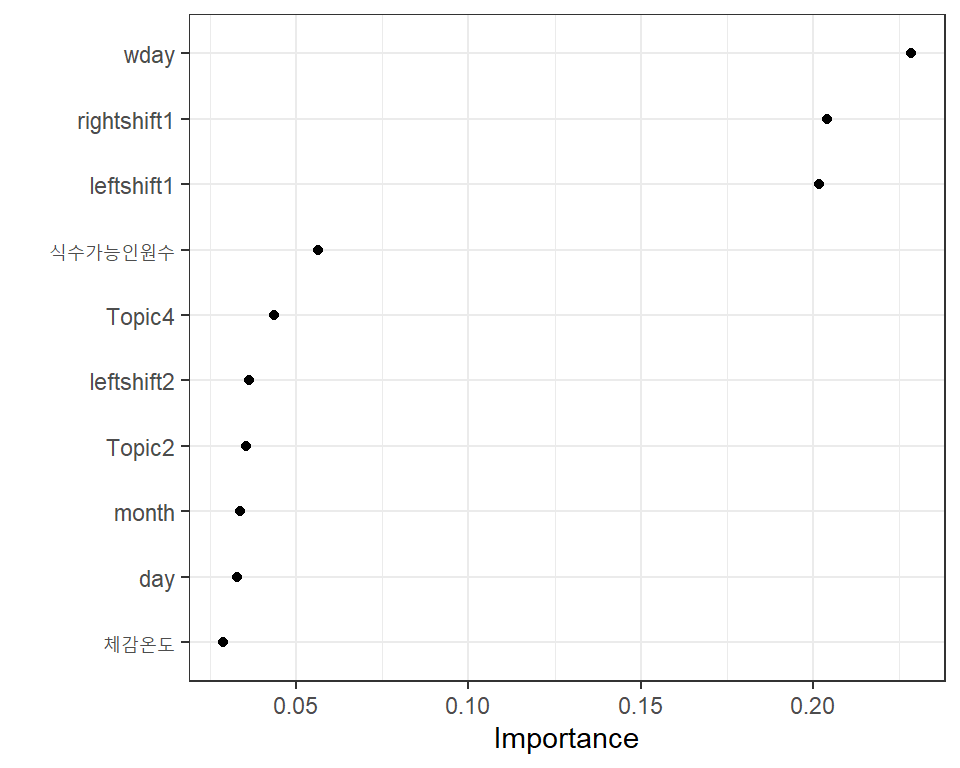

```r
library(vip)
xgb_fit_lunch %>%
        pull_workflow_fit() %>%
        vip(geom = 'point')
```

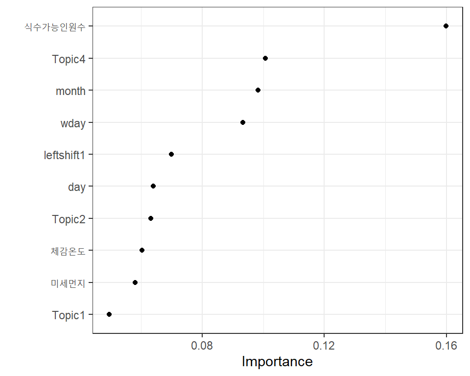

```r
xgb_fit_dinner %>%
        pull_workflow_fit() %>%
        vip(geom = 'point')
```

## 13.5 prediction

```r
pred_xgb_lunch <-
        predict(xgb_fit_lunch, test_lunch) %>%
        round()

pred_xgb_dinner <-
        predict(xgb_fit_dinner, test_dinner) %>%
        round()


sample_submission <- fread(file.path(file_path, "sample_submission.csv"), encoding = 'UTF-8')

sample_submission$중식계 <- pred_xgb_lunch
sample_submission$석식계 <- pred_xgb_dinner

write.csv(sample_submission, 'xgb_fit.csv', row.names = F, fileEncoding = 'UTF-8')
```

# 14 Random forest

## 14.1 Random forest workflow

```r
rf_spec <- rand_forest(
        trees = 1000,
        mtry = tune(),
        min_n = tune()
        ) %>% set_engine('ranger') %>%
        set_mode('regression')

rf_grid_lunch <- grid_latin_hypercube(
  min_n(),
  finalize(mtry(), train_lunch),
  size = 30
)

rf_grid_dinner <- grid_latin_hypercube(
  min_n(),
  finalize(mtry(), train_dinner),
  size = 30
)

rf_wf_lunch <- workflow() %>%
        add_formula(중식계~.) %>%
        add_model(rf_spec)

rf_wf_dinner <- workflow() %>%
        add_formula(석식계~.) %>%
        add_model(rf_spec)
```

## 14.2 rf tuning

```r
library(tictoc)
library(doParallel)
all_cores <- parallel::detectCores(logical = FALSE)-1
registerDoParallel(cores = all_cores)

tic()
rf_res_lunch <- tune_grid(
    rf_wf_lunch,
    resamples = vb_folds_lunch,
    grid = rf_grid_lunch,
    control = ctrl_grid
)
toc() # 292.36
```

```
## 61.75 sec elapsed
```

```r
tic()
rf_res_dinner <- tune_grid(
    rf_wf_dinner,
    resamples = vb_folds_dinner,
    grid = rf_grid_dinner,
    control = ctrl_grid
)
toc() # 283.36
```

```
## 51.75 sec elapsed
```

## 14.3 model fitting

```r
best_param_rf_lunch <- select_best(rf_res_lunch)
best_param_rf_dinner <- select_best(rf_res_dinner)
final_rf_lunch <- finalize_workflow(rf_wf_lunch, best_param_rf_lunch)
final_rf_dinner <- finalize_workflow(rf_wf_dinner, best_param_rf_dinner)

rf_fit_lunch <- fit(final_rf_lunch, data = train_lunch)
rf_fit_dinner <- fit(final_rf_dinner, data = train_dinner)
```

## 14.4 prediction

```r
pred_rf_lunch <-
        predict(rf_fit_lunch, test_lunch) %>%
        round()

pred_rf_dinner <-
        predict(rf_fit_dinner, test_dinner) %>%
        round()


sample_submission <- fread(file.path(file_path, "sample_submission.csv"), encoding = 'UTF-8')

sample_submission$중식계 <- pred_rf_lunch
sample_submission$석식계 <- pred_rf_dinner

write.csv(sample_submission, 'rf_fit.csv', row.names = F, fileEncoding = 'UTF-8')
```

# 15 Lasso, ridge, elastic net

## 15.1 workflow

```r
# LASSO
lasso_spec <- linear_reg(penalty = tune(), mixture = 1) %>% # mixture = 1 : LASSO, 0 : ridge
  set_engine("glmnet")

# Ridge
ridge_spec <- linear_reg(penalty = tune(), mixture = 0) %>% # mixture = 1 : LASSO, 0 : ridge
  set_engine("glmnet")

# elastic net
elastic_spec <- linear_reg(penalty = tune(), mixture = tune()) %>%
  set_engine("glmnet")

lasso_ridge_grid <- grid_regular(
  penalty(), levels = 30
)

elastic_grid <- grid_regular(
  penalty(), mixture(), levels = 30
)

lasso_wf_lunch <- workflow() %>%
        add_formula(중식계~.) %>%
        add_model(lasso_spec)

lasso_wf_dinner <- workflow() %>%
        add_formula(석식계~.) %>%
        add_model(lasso_spec)

ridge_wf_lunch <- workflow() %>%
        add_formula(중식계~.) %>%
        add_model(ridge_spec)

ridge_wf_dinner <- workflow() %>%
        add_formula(석식계~.) %>%
        add_model(ridge_spec)

elastic_wf_lunch <- workflow() %>%
        add_formula(중식계~.) %>%
        add_model(elastic_spec)

elastic_wf_dinner <- workflow() %>%
        add_formula(석식계~.) %>%
        add_model(elastic_spec)
```

## 15.2 hyparameter tuning

```r
library(tictoc)
library(doParallel)
all_cores <- parallel::detectCores(logical = FALSE)-1
registerDoParallel(cores = all_cores)

tic()
lasso_res_lunch <- tune_grid(
    lasso_wf_lunch,
    resamples = vb_folds_lunch,
    grid = lasso_ridge_grid,
    control = ctrl_grid
)
toc() # 16.36
```

```
## 5.07 sec elapsed
```

```r
tic()
lasso_res_dinner <- tune_grid(
    lasso_wf_dinner,
    resamples = vb_folds_dinner,
    grid = lasso_ridge_grid,
    control = ctrl_grid
)
toc() # 4.19
```

```
## 1.17 sec elapsed
```

```r
tic()
ridge_res_lunch <- tune_grid(
    ridge_wf_lunch,
    resamples = vb_folds_lunch,
    grid = lasso_ridge_grid,
    control = ctrl_grid
)
toc() # 16.36
```

```
## 0.81 sec elapsed
```

```r
tic()
ridge_res_dinner <- tune_grid(
    ridge_wf_dinner,
    resamples = vb_folds_dinner,
    grid = lasso_ridge_grid,
    control = ctrl_grid
)
toc() # 44.19
```

```
## 0.8 sec elapsed
```

```r
tic()
elastic_res_lunch <- tune_grid(
    elastic_wf_lunch,
    resamples = vb_folds_lunch,
    grid = elastic_grid,
    control = ctrl_grid
)
toc() # 109.2
```

```
## 18.54 sec elapsed
```

```r
tic()
elastic_res_dinner <- tune_grid(
    elastic_wf_dinner,
    resamples = vb_folds_dinner,
    grid = elastic_grid,
    control = ctrl_grid
)
toc() # 130
```

```
## 18.13 sec elapsed
```

## 15.3 model fitting

```r
best_param_lasso_lunch <- select_best(lasso_res_lunch)
best_param_lasso_dinner <- select_best(lasso_res_dinner)
final_lasso_lunch <- finalize_workflow(lasso_wf_lunch, best_param_lasso_lunch)
final_lasso_dinner <- finalize_workflow(lasso_wf_dinner, best_param_lasso_dinner)

lasso_fit_lunch <- fit(final_lasso_lunch, data = train_lunch)
lasso_fit_dinner <- fit(final_lasso_dinner, data = train_dinner)

best_param_ridge_lunch <- select_best(ridge_res_lunch)
best_param_ridge_dinner <- select_best(ridge_res_dinner)
final_ridge_lunch <- finalize_workflow(ridge_wf_lunch, best_param_ridge_lunch)
final_ridge_dinner <- finalize_workflow(ridge_wf_dinner, best_param_ridge_dinner)

ridge_fit_lunch <- fit(final_ridge_lunch, data = train_lunch)
ridge_fit_dinner <- fit(final_ridge_dinner, data = train_dinner)

best_param_elastic_lunch <- select_best(elastic_res_lunch)
best_param_elastic_dinner <- select_best(elastic_res_dinner)
final_elastic_lunch <- finalize_workflow(elastic_wf_lunch, best_param_elastic_lunch)
final_elastic_dinner <- finalize_workflow(elastic_wf_dinner, best_param_elastic_dinner)

elastic_fit_lunch <- fit(final_elastic_lunch, data = train_lunch)
elastic_fit_dinner <- fit(final_elastic_dinner, data = train_dinner)
```

# 16 stacking

## 16.1 blending

```r
stacking_model_lunch <-
  # initialize the stack
  stacks() %>%
  # add candidate members
  add_candidates(lasso_res_lunch) %>%
  add_candidates(ridge_res_lunch) %>%
  add_candidates(elastic_res_lunch) %>%
  add_candidates(xgb_res_lunch) %>%
  add_candidates(rf_res_lunch) %>%
  # determine how to combine their predictions
  blend_predictions() %>%
  # fit the candidates with nonzero stacking coefficients
  fit_members()
stacking_model_dinner <-
        # initialize the stack
        stacks() %>%
        # add candidate members
        add_candidates(lasso_res_dinner) %>%
        add_candidates(ridge_res_dinner) %>%
        add_candidates(elastic_res_dinner) %>%
        add_candidates(xgb_res_dinner) %>%
        add_candidates(rf_res_dinner) %>%
        # determine how to combine their predictions
        blend_predictions() %>%
        # fit the candidates with nonzero stacking coefficients
        fit_members()
stacking_pred_lunch <-
  test_lunch %>%
  bind_cols(predict(stacking_model_lunch, .))

stacking_pred_dinner <-
  test_dinner %>%
  bind_cols(predict(stacking_model_dinner, .))

stacking_pred_dinner
```

```
## # A tibble: 50 x 28
##    month  wday   day Topic1 Topic2 Topic3 Topic4 체감온도  폭염 미세먼지
##    <dbl> <dbl> <dbl>  <dbl>  <dbl>  <dbl>  <dbl>    <dbl> <dbl>    <dbl>
##  1     1     5    27  0.656 0.146  0.0565 0.142    10.9       0     32.1
##  2     1     3    28  0.234 0.528  0.151  0.0872    3.08      0     45.9
##  3     1     4    29  0.252 0.141  0.269  0.338    -1.76      0     39.4
##  4     2     1     1  0.574 0.162  0.0630 0.201     9.72      0     49.2
##  5     2     2     2  0.273 0.242  0.200  0.285    -0.571     0     14.5
##  6     2     5     3  0.501 0.120  0.103  0.277     1.53      0     29.8
##  7     2     3     4  0.181 0.156  0.240  0.424     6.55      0     22.8
##  8     2     4     5  0.340 0.0877 0.0783 0.494     5.76      0     26.6
##  9     2     1     8  0.531 0.214  0.105  0.151     2.43      0     17.2
## 10     2     2     9  0.228 0.609  0.0911 0.0724    5.21      0     24.1
## # ... with 40 more rows, and 18 more variables: leftshift1 <dbl>,
## #   leftshift2 <dbl>, rightshift1 <dbl>, rightshift2 <dbl>, 석식계 <lgl>,
## #   식수가능인원수 <int>, 강우여부 <dbl>, year_X2016 <dbl>, year_X2017 <dbl>,
## #   year_X2018 <dbl>, year_X2019 <dbl>, year_X2020 <dbl>, year_X2021 <dbl>,
## #   불쾌지수_X.35.68. <dbl>, 불쾌지수_X.68.75. <dbl>, 불쾌지수_X.75.80. <dbl>,
## #   불쾌지수_X.80.84.3. <dbl>, .pred <dbl>
```

```r
stacking_pred_lunch
```

```
## # A tibble: 50 x 28
##    month  wday   day Topic1 Topic2 Topic3 Topic4 체감온도  폭염 미세먼지
##    <dbl> <dbl> <dbl>  <dbl>  <dbl>  <dbl>  <dbl>    <dbl> <dbl>    <dbl>
##  1     1     5    27  0.656 0.146  0.0565 0.142    10.9       0     32.1
##  2     1     3    28  0.234 0.528  0.151  0.0872    3.08      0     45.9
##  3     1     4    29  0.252 0.141  0.269  0.338    -1.76      0     39.4
##  4     2     1     1  0.574 0.162  0.0630 0.201     9.72      0     49.2
##  5     2     2     2  0.273 0.242  0.200  0.285    -0.571     0     14.5
##  6     2     5     3  0.501 0.120  0.103  0.277     1.53      0     29.8
##  7     2     3     4  0.181 0.156  0.240  0.424     6.55      0     22.8
##  8     2     4     5  0.340 0.0877 0.0783 0.494     5.76      0     26.6
##  9     2     1     8  0.531 0.214  0.105  0.151     2.43      0     17.2
## 10     2     2     9  0.228 0.609  0.0911 0.0724    5.21      0     24.1
## # ... with 40 more rows, and 18 more variables: leftshift1 <dbl>,
## #   leftshift2 <dbl>, rightshift1 <dbl>, rightshift2 <dbl>, 중식계 <lgl>,
## #   식수가능인원수 <int>, 강우여부 <dbl>, year_X2016 <dbl>, year_X2017 <dbl>,
## #   year_X2018 <dbl>, year_X2019 <dbl>, year_X2020 <dbl>, year_X2021 <dbl>,
## #   불쾌지수_X.35.68. <dbl>, 불쾌지수_X.68.75. <dbl>, 불쾌지수_X.75.80. <dbl>,
## #   불쾌지수_X.80.84.3. <dbl>, .pred <dbl>
```

## 16.2 prediction

```r
stacking_pred_lunch <- stacking_pred_lunch %>%
        round()

stacking_pred_dinner <- stacking_pred_dinner %>%
        round()


sample_submission <- fread(file.path(file_path, "sample_submission.csv"), encoding = 'UTF-8')

sample_submission$중식계 <- stacking_pred_lunch$.pred
sample_submission$석식계 <- stacking_pred_dinner$.pred

write.csv(sample_submission, 'stacking_fit.csv', row.names = F, fileEncoding = 'UTF-8')
```